# Splatter Simulation and JIVE Integration

Joey Hastings

2023-02-10

# Load Packages

```r
library(tictoc)
library(tidyverse)
library(cowplot)
library(ggExtra)
library(ggthemes)

library(splatter)
library(scater)
library(scran)
library(r.jive)
library(Seurat)
library(factoextra)
library(SLIDE)

library(kBET) # kBET
library(cluster) # ASW
library(lisi) # LISI
library(mclust) # ARI

theme_set(theme_few())
```

# Simulation 1

## Generate Cell Counts

- Three cell types/groups (unbalanced)
- Two batches (balanced)
- Small dropout

```r
# Parameters that remain the same for all cell types
nGenes <- 5000
method = "single"
dropout.type = "experiment"
dropout.shape = -1
verbose = FALSE
```

```r
tic("Data Simulation")
sim1 <- splatSimulate(
  # Parameters to tweak in each simulation
  batchCells = c(500, 500),
  batch.facLoc = c(0.001, 0.5),
  batch.facScale = c(0.001, 0.5),
  dropout.mid = 0.05,
  # Parameters to remain the same
  nGenes = nGenes,
  method = "groups",
  seed = 1,
  dropout.type = dropout.type,
  dropout.shape = dropout.shape,
  group.prob = c(0.6, 0.3, 0.1),
  de.prob = c(0.01, 0.1, 0.5),
  de.downProb = c(0.01, 0.4, 0.9),
  de.facLoc = c(0.6, 1, 0.2),
  de.facScale = c(0.1, 0.4, 0.8),
  verbose = verbose
  )
toc()
```

```
## Data Simulation: 4.62 sec elapsed
```

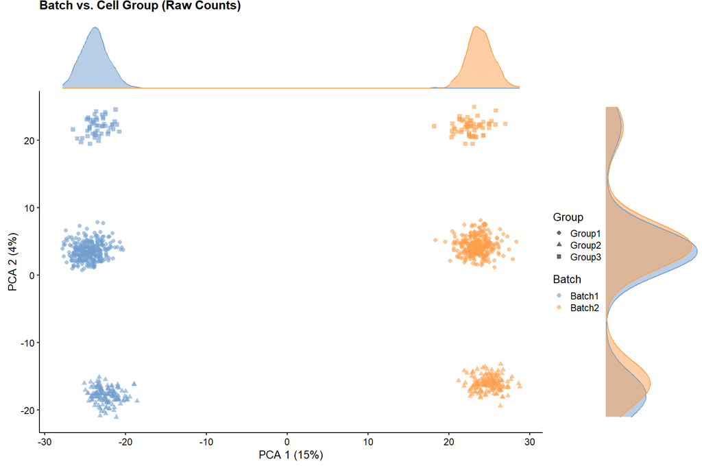

```r
sim1 <- logNormCounts(sim1)

# Dimension reduction visualization
set.seed(1)
sim1 <- runPCA(sim1, ncomponents = 30, ntop = 2000)
orig_p1 <- plotPCA(sim1, color_by = "Batch", shape_by = "Group") +
  labs(title = "Batch vs. Cell Group (Raw Counts)")
orig_marg <- ggMarginal(orig_p1, type = "density", groupColour = TRUE, groupFill = TRUE)

orig_marg
```

## Separate Batches

```r
batches <- sim1$Batch
# Frequency of batches in simulation
table(batches)
```

```
## batches
## Batch1 Batch2
##    500    500
```

```r
groups <- sim1$Group
# Frequency of cell types in simulation
table(groups)
```

```
## groups
## Group1 Group2 Group3
##    606    284    110
```

```r
rawcounts <- counts(sim1)
dim(rawcounts)
```

```
## [1] 5000 1000
```

```r
b1 <- rawcounts[, batches == "Batch1"]
grp_b1 <- groups[batches == "Batch1"]
# Dimension of batch 1
dim(b1)
```

```
## [1] 5000  500
```

```r
# Frequency of cell types in batch 1
table(grp_b1)
```

```
## grp_b1
## Group1 Group2 Group3
##    312    136     52
```

```r
b2 <- rawcounts[, batches == "Batch2"]
grp_b2 <- groups[batches == "Batch2"]
# Dimension of batch 2
dim(b2)
```

```
## [1] 5000  500
```

```r
# Frequency of cell types in batch 2
table(grp_b2)
```

```
## grp_b2
## Group1 Group2 Group3
##    294    148     58
```

## Compare Batches

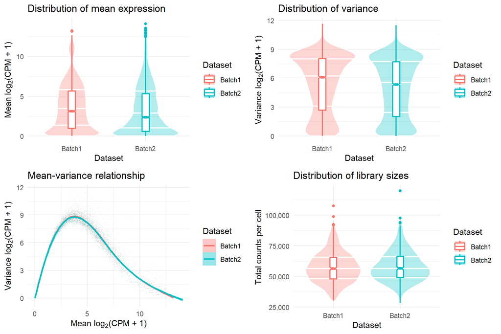

```r
# Convert count matrices for batch 1 and 2 in to SCE objects for comparison via splatter
b1_sce <- SingleCellExperiment(list(counts = b1))
b2_sce <- SingleCellExperiment(list(counts = b2))

comparison <- compareSCEs(
  list(
    Batch1 = b1_sce,
    Batch2 = b2_sce
    )
  )

plot_grid(plotlist = comparison$Plots[1:4])
```

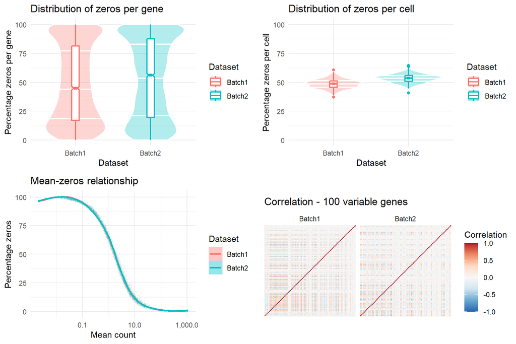

```r
plot_grid(plotlist = comparison$Plots[5:8])
```

## JIVE

This time we transpose the matrices so that the common genes ($n$ = 5000) are the columns and the cells are the rows:

````r
#```{r jive1}
sim1_data <- NULL
sim1_data$Batch1 <- t(b1)
sim1_data$Batch2 <- t(b2)

set.seed(1)

# Permutation
tic("JIVE Analysis (Permutation)")
JIVE_results_default <- jive(sim1_data, rankJ = 2, rankA = c(3, 3))
toc()

saveRDS(JIVE_results_default, file = "data/JIVE_results2_perm.rds")

# BIC
# tic("JIVE Analysis (BIC)")
# JIVE_results_bic <- jive(sim1_data, method = "bic") # did not converge over multiple days
# toc()
#
# saveRDS(JIVE_results_bic, file = "data/JIVE_results2_bic.rds")
````

Summary of estimated ranks and variance explained by joint/individual/residual for each approach:

```r
JIVE_results_default <- readRDS(file = "data/JIVE_results2_perm.rds")
summary(JIVE_results_default)
```

```
## $Method
## [1] "given"
##
## $Ranks
##      Source   Rank
## [1,] "Joint"  "2"
## [2,] "Batch1" "3"
## [3,] "Batch2" "3"
##
## $Variance
##            Batch1 Batch2
## Joint       0.590  0.937
## Individual  0.364  0.019
## Residual    0.046  0.045
```

```r
# JIVE_results_bic <- readRDS(file = "JIVE_results2_bic.rds")
# summary(JIVE_results_bic)
```

### Visualization using PCA

Visualize the principal components of the joint portion of the JIVE decomposition:

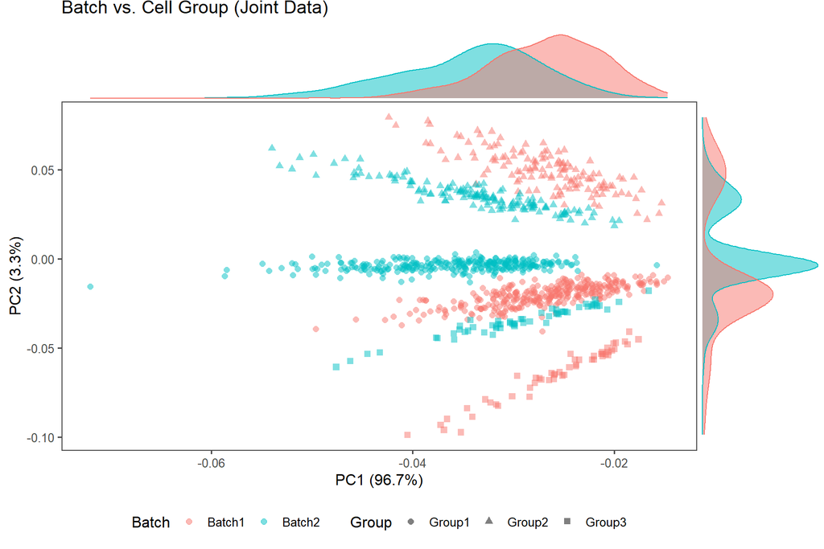

```r
JIVE_results <- JIVE_results_default

# showPCA(JIVE_results, 2)

joint <- do.call(rbind, JIVE_results$joint)

# PCA
# joint_prcomp <- prcomp(joint, scale. = T)
# joint_pc <- joint_prcomp[["x"]] %>%
#   as.data.frame() %>%
#   select(PC1, PC2) %>%
#   mutate(
#     Batch = batches,
#     Group = c(grp_b1, grp_b2)
#   )
#
# pc1_var_expl <- round(summary(joint_prcomp)[["importance"]][2, 1] * 100, digits = 1)
# pc2_var_expl <- round(summary(joint_prcomp)[["importance"]][2, 2] * 100, digits = 1)

# SVD
joint_svd <- svd(joint)
joint_pc <- joint_svd$u %>%
  as.data.frame() %>%
  select(PC1 = V1, PC2 = V2) %>%
  mutate(
    Batch = batches,
    Group = c(grp_b1, grp_b2)
  )

# https://genomicsclass.github.io/book/pages/pca_svd.html
svd_var_expl <- joint_svd$d^2 / sum(joint_svd$d^2)
pc1_var_expl <- round(svd_var_expl[1] * 100, digits = 1)
pc2_var_expl <- round(svd_var_expl[2] * 100, digits = 1)

# Plot
p <- ggplot(data = joint_pc) +
  geom_point(
    aes(x = PC1, y = PC2, color = Batch, shape = Group),
    alpha = 0.5, size = 2
  ) +
  labs(
    x = paste0("PC1 (", pc1_var_expl, "%)"),
    y = paste0("PC2 (", pc2_var_expl, "%)")
    ) +
  theme(legend.position = "bottom") +
  labs(title = "Batch vs. Cell Group (Joint Data)")

marg_p <- ggMarginal(p, type = "density", groupColour = TRUE, groupFill = TRUE)
marg_p
```

### Visualization using `SCE`

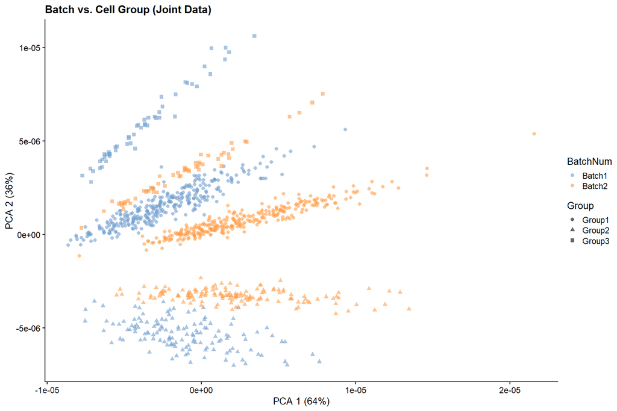

```r
JIVE_joint_b1_SCE <- SingleCellExperiment(list(logcounts = t(JIVE_results[["joint"]][[1]])))
colData(JIVE_joint_b1_SCE)$Group <- grp_b1
colData(JIVE_joint_b1_SCE)$BatchNum <- "Batch1"

JIVE_joint_b2_SCE <- SingleCellExperiment(list(logcounts = t(JIVE_results[["joint"]][[2]])))
colData(JIVE_joint_b2_SCE)$Group <- grp_b2
colData(JIVE_joint_b2_SCE)$BatchNum <- "Batch2"

JIVE_joint_SCE <- cbind(JIVE_joint_b1_SCE, JIVE_joint_b2_SCE)

set.seed(1)
JIVE_joint_SCE <- runPCA(JIVE_joint_SCE, ncomponents = 30, ntop = 2000)
# JIVE_joint_SCE <- runTSNE(JIVE_joint_SCE)
# JIVE_joint_SCE <- runUMAP(JIVE_joint_SCE)

clusters <- clusterCells(
  JIVE_joint_SCE,
  use.dimred = "PCA",
  BLUSPARAM = bluster::SNNGraphParam(
    cluster.fun = "louvain",
    cluster.args = list(resolution = 0.5)
    )
  )

colData(JIVE_joint_SCE)$Cluster <- clusters

# By Batch/Group
jive_p1 <- plotPCA(JIVE_joint_SCE, color_by = "BatchNum", shape_by = "Group")
jive_p1 + labs(title = "Batch vs. Cell Group (Joint Data)")
```

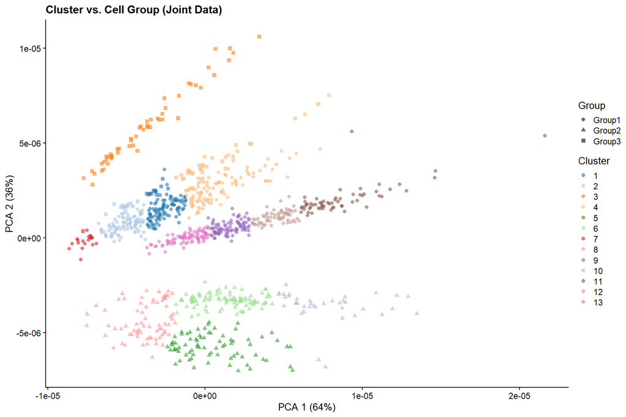

```r
# By Cluster/Group
jive_p2 <- plotPCA(JIVE_joint_SCE, color_by = "Cluster", shape_by = "Group")
jive_p2 + labs(title = "Cluster vs. Cell Group (Joint Data)")
```

### Calculate kBET

- Sub-sample data at varying percentages
  - 5%, 10%, 15%, 20%, 25%
  - Stratified sampling so that each batch has the same number of cells selected
    - E.g., assume 2 batches, sampling 10% of 1000 cells = 100 cells: sample 50 cells from each batch
- Calculate kBET rejection rates at each percentage
  - **Lower** RR indicate well-mixed batches
  - **Higher** RR indicate poorly-mixed batches

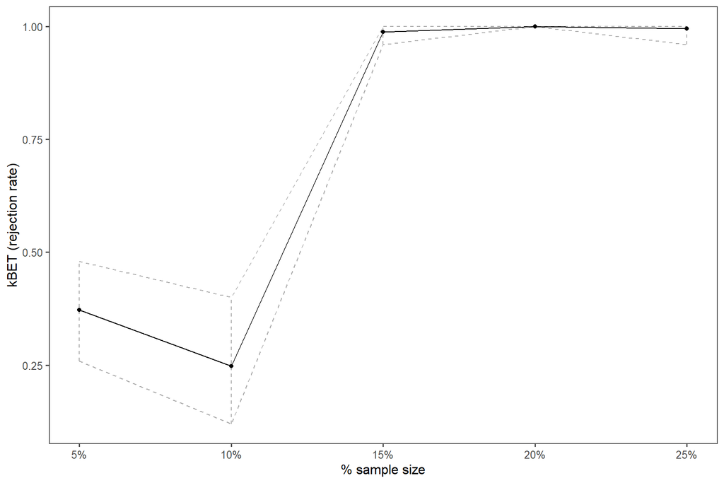

```r
# data: a matrix (rows: samples, columns: features (genes))
data <- joint

# batch: vector or factor with batch label of each cell
batch <- batches

sample_size <- seq(0.05, 0.25, 0.05)
rejection_rate <- list()

set.seed(1)
for (i in sample_size) {
  subset_prop <- i # subsample to 10% of the data
  subset_size_total <- floor(length(batch) * subset_prop)
  subset_size_per_batch <- floor(subset_size_total / length(unique(batch)))

  subset_index <-
    data.frame(index = 1:length(batch) , batch = batch) %>%
    group_by(batch) %>%
    slice_sample(n = subset_size_per_batch, replace = F)

  table(subset_index$batch)

  subset_id <- subset_index %>%
    pull(index)

  batch.estimate <- kBET(data[subset_id,], batch[subset_id], plot = F)

  rejection_rate[[which(sample_size == i)]] <- batch.estimate$summary %>%
    rownames_to_column(var = "statistic") %>%
    mutate(sample_size = i, n_batch = subset_size_per_batch) %>%
    select(sample_size, n_batch, statistic, kBET_rr = kBET.observed)
}

all_rr <- bind_rows(rejection_rate) %>%
  pivot_wider(id_cols = c(sample_size, n_batch), names_from = statistic, values_from = kBET_rr)

all_rr %>%
  ggplot(aes(x = sample_size, y = mean)) +
  geom_line(aes(y = `97.5%`), color = "darkgray", linetype = "dashed") +
  geom_line(aes(y = `2.5%`), color = "darkgray", linetype = "dashed") +
  geom_line() +
  # geom_line(aes(y = `97.5%`), color = "darkgray") +
  geom_linerange(aes(ymin = `2.5%`, ymax = `97.5%`), color = "darkgray", linetype = "dashed") +
  geom_point() +
  scale_x_continuous(labels = scales::percent) +
  labs(x = "% sample size", y = "kBET (rejection rate)")
```

### Calculate Average Silhouette Width

Original batch label and cell types/groups will be considered the clusters to compute $ASW_{batch}$ and $ASW_{group}$

```r
asw_repeat <- 20
npcs <- 30

asw_batch <- list()
asw_group <- list()
subset_prop <- 0.8 # subsample to 80% of the data
subset_size_total <- floor(length(batch) * subset_prop)

set.seed(1)
for (i in 1:asw_repeat) {
  subset_index <-
    data.frame(index = 1:length(batch) , batch = batch) %>%
    slice_sample(n = subset_size_total, replace = F)

  subset_id <- subset_index %>%
    pull(index)

  asw_batch_i <- silhouette(as.integer(factor(batches[subset_id])), dist(joint[subset_id, 1:npcs]))
  asw_batch[[i]] <- as.data.frame(rbind(summary(asw_batch_i)[["si.summary"]]))

  asw_group_i <- silhouette(as.integer(factor(groups[subset_id])), dist(joint[subset_id, 1:npcs]))
  asw_group[[i]] <- as.data.frame(rbind(summary(asw_group_i)[["si.summary"]]))
}

all_asw_batch <- bind_rows(asw_batch) %>%
  mutate(cluster = "Batch")

# ASW_batch summary
summary(all_asw_batch$Mean)
```

```
##    Min. 1st Qu.  Median    Mean 3rd Qu.    Max.
## 0.08771 0.09014 0.09246 0.09213 0.09432 0.09545
```

```r
all_asw_group <- bind_rows(asw_group) %>%
  mutate(cluster = "Group")

#ASW_group summary
summary(all_asw_group$Mean)
```

```
##    Min. 1st Qu.  Median    Mean 3rd Qu.    Max.
##  0.3855  0.3960  0.3999  0.4031  0.4109  0.4238
```

### Calculate LISI Scores

```r
# Performed for all cells

batch_lisi <- compute_lisi(joint, data.frame(batch = batches), label_colnames = "batch")

# Looking for values close to the number of batches (2)
summary(batch_lisi)
```

```
##      batch
##  Min.   :1.000
##  1st Qu.:1.003
##  Median :1.027
##  Mean   :1.147
##  3rd Qu.:1.136
##  Max.   :2.000
```

```r
group_lisi <- compute_lisi(joint, data.frame(group = groups), label_colnames = "group")

# Looking for values close to 1
summary(group_lisi)
```

```
##      group
##  Min.   :1.000
##  1st Qu.:1.000
##  Median :1.000
##  Mean   :1.082
##  3rd Qu.:1.033
##  Max.   :2.000
```

### Calculate Adjusted Rand Index

Original batch label and cell types/groups will be compared against the Louvain clusters to compute $ARI_{batch}$ and $ARI_{group}$.

- Compute adjusted rand index (ARI) for the first 30 PCs of 80% sub-sample of joint data
  - ARI ranges between 0 and 1
  - Values **close to 1** indicate the two partition labels are similar
  - Values **close to 0** indicate the two partition labels are not similar
    - We hope to see lower values for $ARI_{batch}$ since it is indicative of well-mixed batches
    - We hope to see higher values for $ARI_{group}$ since it is indicative that distinct cell groups were preserved after batch-mixing
- Repeat `20` times
- Calculate the median ASW from the `20` runs to ensure stability of the measurement

```r
ari_repeat <- 20
npcs <- 30

ari_batch <- list()
ari_group <- list()
subset_prop <- 0.8 # subsample to 80% of the data
subset_size_total <- floor(length(batch) * subset_prop)

set.seed(1)
for (i in 1:ari_repeat) {
  subset_index <-
    data.frame(index = 1:length(batch) , batch = batch) %>%
    slice_sample(n = subset_size_total, replace = F)

  subset_id <- subset_index %>%
    pull(index)

  ari_batch[[i]] <- adjustedRandIndex(factor(batches[subset_id]), clusters[subset_id])
  ari_group[[i]] <- adjustedRandIndex(factor(groups[subset_id]), clusters[subset_id])
}

all_ari_batch <- data.frame(ari = unlist(ari_batch)) %>%
  mutate(cluster = "Batch")

# Lower values indicate well-mixed batches
summary(all_ari_batch$ari)
```

```
##    Min. 1st Qu.  Median    Mean 3rd Qu.    Max.
##  0.1087  0.1155  0.1164  0.1163  0.1170  0.1215
```

```r
all_ari_group <- data.frame(ari = unlist(ari_group)) %>%
  mutate(cluster = "Group")

# Higher values indicate cell types were well preserved
summary(all_ari_group$ari)
```

```
##    Min. 1st Qu.  Median    Mean 3rd Qu.    Max.
##  0.1502  0.1533  0.1555  0.1562  0.1592  0.1655
```